# Analyze FACS data

David Gresham

05 August, 2020

This Vignette written as an [R Markdown](http://rmarkdown.rstudio.com) Notebook provides a simple example of importing FACS data from different machines, annotating the samples and visualizing the results.

The data are generated using the three FACS machines used in NYU CGSB gencore

1. Accuri
2. Aria
3. Cytek

# Example Data

Below are the data that are used in this vignette. To work through this analysis:

1. Download all directories and files from [here](https://drive.google.com/drive/folders/1_QARsH5vOHR-lIPURf3lgt6skN2of5US?usp=sharing)
2. Organize directories with the following structure.

You can see that there are three different directories `/Accuri` , `/Aria` and `/Cytek` that contain different .fcs files and samplesheets

```bash
echo '/Users/david/Projects/Data/flowdata'
ls -R /Users/david/Projects/Data/flowdata
```

```
## /Users/david/Projects/Data/flowdata
## Accuri
## Aria
## Cytek
## Icon
##
## /Users/david/Projects/Data/flowdata/Accuri:
## E07.fcs
## E08.fcs
## E09.fcs
## E10.fcs
## E11.fcs
## E12.fcs
## F07.fcs
## F08.fcs
## F09.fcs
## F10.fcs
## F11.fcs
## F12.fcs
## G07.fcs
## G08.fcs
## G09.fcs
## G10.fcs
## G11.fcs
## G12.fcs
## GAP1_multicheck_20May2019.xlsx
## H07.fcs
## Icon
## SampleSheet.csv
##
## /Users/david/Projects/Data/flowdata/Aria:
## A01.fcs
## A02.fcs
## A03.fcs
## A04.fcs
## A05.fcs
## B03.fcs
## Icon
## Sample_Sheet.xlsx
##
```

[output cut: 16 more lines]

```
## Test 3-2-2020-Group_001-1744-3_Unmixed.fcs
## Test 3-2-2020-Group_001-1744.fcs
## Test 3-2-2020-Group_001-1744_Unmixed.fcs
## Test 3-2-2020-Group_001-2300.fcs
## Test 3-2-2020-Group_001-2300_Unmixed.fcs
## Test 3-2-2020-Group_001-2323.fcs
## Test 3-2-2020-Group_001-2323_Unmixed.fcs
## Test 3-2-2020-Group_001-unstained.fcs
## Test 3-2-2020-Group_001-unstained_Unmixed.fcs
## samplesheet_cytek.xlsx
##
## /Users/david/Projects/Data/flowdata/Cytek/PDF:
## Grace TEST.PDF
## Great test.PDF
## Icon
```

# Load required libraries

Several packages are required for running this analysis. If they are not installed, you need to run the following commands the first time:

## Install Libraries

This workflow uses a variety of Bioconductor packages that should be loaded using: `BiocManager::install()` as per these [guidelines](https://www.bioconductor.org/install/).

```r
#if (!requireNamespace("BiocManager", quietly = TRUE))
#    install.packages("BiocManager")
#BiocManager::install()
#BiocManager::install(ncdfFlow)
#BiocManager::install(flowCore)
#BiocManager::install(flowViz)
#BiocManager::install(ggcyto)
#BiocManager::install(ggforce)


#install.packages(tidyverse)
#install.packages(ggridges)
```

## Loading the Gresham Lab’s `flowtools` from [github](https://github.com/GreshamLab/flowtools)

```r
#install.packages(devtools)
#devtools::install_github("greshamlab/flowtools")
```

## Load libraries

This workflow using the following packages (include linkes to vignettes using packages)

- [flowCore](https://www.bioconductor.org/packages/release/bioc/vignettes/flowCore/inst/doc/HowTo-flowCore.pdf), which provides several functions for reading and manipulating .fcs files.
- [ncdfFlow](https://bioconductor.org/packages/devel/bioc/vignettes/ncdfFlow/inst/doc/ncdfFlow.pdf), which reads .fcs files to disk rather than memory. This allows import of larger datasets as they do not need to be stored in memory.
- [ggcyto](https://www.bioconductor.org/packages/release/bioc/html/ggcyto.html)
  - [basic functions](https://www.bioconductor.org/packages/release/bioc/vignettes/ggcyto/inst/doc/Top_features_of_ggcyto.html)
  - [autoplot](https://www.bioconductor.org/packages/release/bioc/vignettes/ggcyto/inst/doc/autoplot.html)
  - [visualize flowset](https://www.bioconductor.org/packages/release/bioc/vignettes/ggcyto/inst/doc/ggcyto.flowSet.html)
  - [visualize gatingset](https://www.bioconductor.org/packages/release/bioc/vignettes/ggcyto/inst/doc/ggcyto.GatingSet.html)

```r
library(ncdfFlow)
```

```r
library(flowCore)
library(flowViz)
library(ggcyto)
library(ggforce)
library(tidyverse)
library(ggridges)
library(readxl)
```

# Visualizing Accuri Data

First we will visualize flow data from the Accuri

## Read files

FCS files exported from the Accuri flow cytometry machine are read into R using `read.ncdfFlowSet`

```r
dir = '/Users/david/Projects/Data/flowdata/Accuri'
files <- sort(list.files(path=dir,pattern = ".fcs", full.names=TRUE))
flowData <- read.ncdfFlowSet(files=files, pattern=".fcs", alter.names = TRUE)
```

```
## All FCS files have the same following channels:
## FSC.A
## SSC.A
## FL1.A
## FL2.A
## FL3.A
## FL4.A
## FSC.H
## SSC.H
## FL1.H
## FL2.H
## FL3.H
## FL4.H
## Width
## Time
```

[output not shown]

[output not shown]

[output not shown]

[output not shown]

[output not shown]

[output not shown]

[output not shown]

[output not shown]

[output not shown]

[output not shown]

[output not shown]

[output not shown]

[output not shown]

[output not shown]

[output not shown]

[output not shown]

[output not shown]

[output not shown]

[output not shown]

[output not shown]

```r
#needs to differ depending on sample sheet file typ
#sample.sheet <- read_excel(paste(path=dir,"GAP1_multicheck_20May2019.xlsx", sep="/"))
SampleSheet <- read_csv("~/Projects/Data/flowdata/Accuri/SampleSheet.csv")
#print(flowData)
#print(summary(flowData))
flowData[[1]]
```

```
## flowFrame object 'E07.fcs'
## with 100000 cells and 14 observables:
##       name  desc    range minRange maxRange
## $P1  FSC.A FSC-A 16777216        0 16777215
## $P2  SSC.A SSC-A 16777216        0 16777215
## $P3  FL1.A FL1-A 16777216        0 16777215
## $P4  FL2.A FL2-A 16777216        0 16777215
## $P5  FL3.A FL3-A 16777216        0 16777215
## $P6  FL4.A FL4-A 16777216        0 16777215
## $P7  FSC.H FSC-H 16777216        0 16777215
## $P8  SSC.H SSC-H 16777216        0 16777215
## $P9  FL1.H FL1-H 16777216        0 16777215
## $P10 FL2.H FL2-H 16777216        0 16777215
## $P11 FL3.H FL3-H 16777216        0 16777215
## $P12 FL4.H FL4-H 16777216        0 16777215
## $P13 Width Width 16777216        0 16777215
## $P14  Time  Time 16777216        0 16777215
## 159 keywords are stored in the 'description' slot
```

## Assign sample names and other metadata

```r
sampleNames(flowData) <- SampleSheet$Strain

pData(flowData)$Well <- SampleSheet$Well
pData(flowData)$Strain <- SampleSheet$Strain
pData(flowData)$Genotype <- SampleSheet$Genotype
pData(flowData)$Ploidy <- SampleSheet$Ploidy
pData(flowData)$Media <- SampleSheet$Media
pData(flowData)
```

|  | name | Well | Strain | Genotype | Ploidy | Media |
| --- | --- | --- | --- | --- | --- | --- |
| DGY1 | E07.fcs | E07 | DGY1 | 0 copy control | 1N | YPD |
| DGY500 | E08.fcs | E08 | DGY500 | 1 copy control | 1N | YPD |
| DGY1315 | E09.fcs | E09 | DGY1315 | 2 copy control | 1N | YPD |
| DGY1657 | E10.fcs | E10 | DGY1657 | GAP1 reporter | 1N | YPD |
| DGY1658 | E11.fcs | E11 | DGY1658 | GAP1 reporter | 1N | YPD |
| DGY1972 | E12.fcs | E12 | DGY1972 | 1 copy @ HO | 1N | YPD |
| DGY1973 | F07.fcs | F07 | DGY1973 | 1 copy @ HO | 1N | YPD |
| DGY1974 | F08.fcs | F08 | DGY1974 | 1 copy @ HO | 1N | YPD |
| DGY2000 | F09.fcs | F09 | DGY2000 | 2 copy HO/endo | 1N | YPD |
| DGY2001 | F10.fcs | F10 | DGY2001 | 2 copy HO/endo | 1N | YPD |

[output cut: 9 more lines]

## See a summary of the data

```r
fsApply(flowData,each_col,median)
```

```
##            FSC.A    SSC.A    FL1.A FL2.A   FL3.A FL4.A     FSC.H    SSC.H
## DGY1    708025.0 111357.5   1872.0   278   676.0   245 1075001.5 151600.0
## DGY500  706858.0 115767.5 184357.5  1822 13254.0  1728 1116047.5 164725.0
## DGY1315 673867.5 109442.0 341691.0  3279 24630.0  3113 1113197.5 162067.5
## DGY1657 678571.0 108559.5 176388.0  1779 12802.0  1697 1119643.5 161552.5
## DGY1658 636788.0  97018.0 166741.0  1732 12166.0  1650 1058990.5 144904.5
## DGY1972 646497.0  96580.5 174775.0  1940 12803.0  1848  966048.0 131518.5
## DGY1973 635552.0  99823.0 162894.0  1673 11871.0  1596 1063489.0 147454.0
## DGY1974 678989.5 107215.0 178133.5  1769 12872.0  1675 1115865.0 157109.0
## DGY2000 635213.5  98545.0 330682.0  3259 23905.0  3101 1044707.5 144460.0
## DGY2001 663436.0 105325.5 357938.0  3455 25850.0  3265 1101761.0 155297.0
## DGY2135 622491.5  97634.0 145818.5  1527 10744.0  1449 1068373.0 147587.5
## DGY2136 658949.0  99015.0 151732.5  1647 11252.0  1576 1100384.0 145737.0
## DGY2143 634325.0 107630.5 172070.0  1750 12671.0  1655 1090845.0 163739.0
## DGY2144 570371.0  85767.0 136492.5  1392  9962.0  1318 1006540.5 132717.0
## DGY2148 650177.0 102916.5 291186.5  2815 21183.0  2653 1105639.0 154959.0
## DGY2158 612864.0  91176.0 283469.0  2852 20535.0  2713 1036767.5 134779.0
## DGY2236 662816.0  96799.0 325685.5  3354 23486.0  3180  990074.0 129721.5
## DGY2237 458943.0  67538.0 281142.5  2876 20468.5  2741  788130.0 100189.0
## DGY2238 483209.0  75201.5 266791.0  2750 19323.5  2624  804562.5 108990.5
##            FL1.H FL2.H   FL3.H FL4.H Width Time
## DGY1      3510.0   271  1412.0   514    60  163
## DGY500  185777.0  1832 13520.0  1821    58  159
## DGY1315 357620.0  3464 25968.0  3332    56  160
## DGY1657 184336.0  1828 13496.5  1814    57  161
## DGY1658 173839.5  1744 12755.0  1738    56  165
## DGY1972 160255.5  1673 11701.0  1722    59  212
## DGY1973 171547.0  1711 12584.0  1705    56  163
## DGY1974 185850.5  1854 13642.0  1819    57  158
## DGY2000 343191.0  3337 24881.0  3226    56  167
## DGY2001 373337.0  3614 27152.0  3472    57  164
## DGY2135 158968.5  1608 11773.5  1591    55  162
## DGY2136 161010.5  1641 11883.0  1649    56  176
## DGY2143 187101.0  1873 13858.0  1832    55  159
## DGY2144 153739.5  1528 11311.0  1506    53  158
## DGY2148 315504.0  3070 23151.0  2935    55  160
## DGY2158 307042.0  2993 22198.5  2886    55  186
## DGY2236 297907.5  2963 21411.0  2916    60  208
## DGY2237 292073.5  2873 21159.5  2799    51  198
## DGY2238 273765.5  2700 19754.0  2641    53  206
```

## Visualize one channel

Using Autoplot

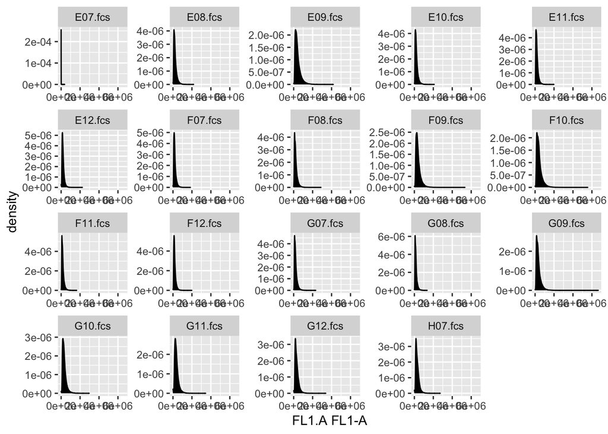

```r
autoplot(flowData, "FL1.A")
```

## Visualize two channels

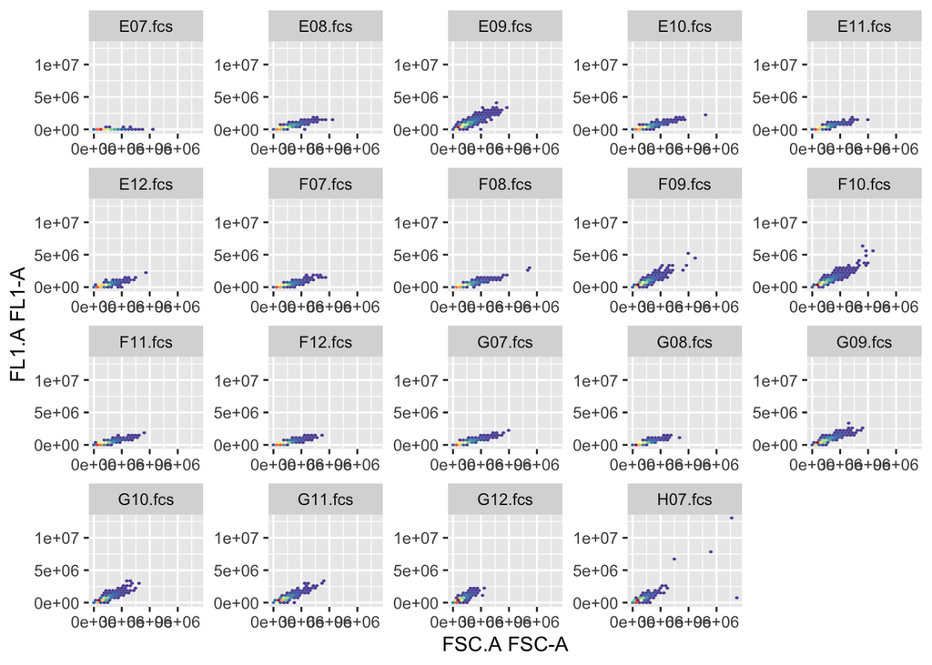

```r
autoplot(flowData, "FSC.A", "FL1.A")
```